# Exercises 5: Introduction to Quarto

- Show All Code
- Hide All Code
- View Source

Author

Affiliation

Guillem Ylla, PhD

Jagiellonian University

## Create a new Quarto document

- In RStudio:
  - “File” -> “New File” -> “Quarto Document”.
    - It will generate a new file with a short example.
- Remember, you have 2 modes “Source” and “Visual” on the begging of the above menuy bar.

## Getting Started

- Text is written in Markdown.
- Before the Markdown, there is the YAML code that sets up some parameters.
  - In this file, you will see my YAML code in which I set up the table of contents (toc), the code to be “folded”
- Code Chunks by default are in R, but you can also use Python/Julia/Bash…
- You can insert new code chunk with **Ctrl+Alt+i**
- Quarto CheatSheet: https://rstudio.github.io/cheatsheets/quarto.pdf

## Run the code

- You can run code **line by line** with **Ctrl+Enter**.
- You can run **whole chunk** with **Ctrl+Shift+Enter**.
- you can run **all chunks** with **Ctrl+Alt+R**.

## Render file

- Top bar “Render”
  - Also **Ctrl+Shift+k**.

### Exercise 1

1. Add a R code chunk.
   - In the chunk define **A** to **10** and **B** to **20**.
   - Show values of A and B.
2. Add another R chunk and sum A+B.
3. Add another chunk and make a barplot of the vector containing A and B `c(A,B)` .
4. Run the code:
   - Line by line.
   - Chunk by chunk.
   - All chunks at once.
5. Render.

### Solution Exercise 1

```r
A<-10
B<-20
```

```r
A+B
```

```
[1] 30
```

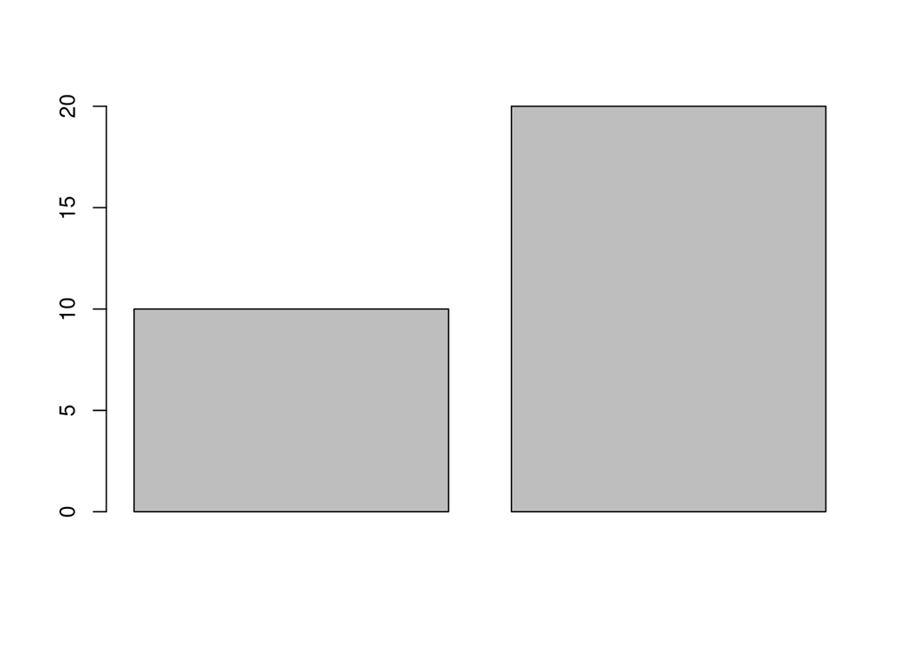

```r
barplot(c(A,B))
```